# Python Project - IPL_data

```python
import pandas as pd
```

```python
df=pd.read_csv("C:/Users/Sudu/Desktop/ETlhive/Python/Python_projects/IPL_Data_analysis/IPL_Dataset.csv")
df
```

|  | match_id | inning | batting_team | bowling_team | over | ball | batsman | non_striker | bowler | is_super_over | ... | bye_runs | legbye_runs | noball_runs | penalty_runs | batsman_runs | extra_runs | total_runs | player_dismissed | dismissal_kind | fielder |
| --- | --- | --- | --- | --- | --- | --- | --- | --- | --- | --- | --- | --- | --- | --- | --- | --- | --- | --- | --- | --- | --- |
| 0 | 1 | 1 | Sunrisers Hyderabad | Royal Challengers Bangalore | 1 | 1 | DA Warner | S Dhawan | TS Mills | 0 | ... | 0 | 0 | 0 | 0 | 0 | 0 | 0 | NaN | NaN | NaN |
| 1 | 1 | 1 | Sunrisers Hyderabad | Royal Challengers Bangalore | 1 | 2 | DA Warner | S Dhawan | TS Mills | 0 | ... | 0 | 0 | 0 | 0 | 0 | 0 | 0 | NaN | NaN | NaN |
| 2 | 1 | 1 | Sunrisers Hyderabad | Royal Challengers Bangalore | 1 | 3 | DA Warner | S Dhawan | TS Mills | 0 | ... | 0 | 0 | 0 | 0 | 4 | 0 | 4 | NaN | NaN | NaN |
| 3 | 1 | 1 | Sunrisers Hyderabad | Royal Challengers Bangalore | 1 | 4 | DA Warner | S Dhawan | TS Mills | 0 | ... | 0 | 0 | 0 | 0 | 0 | 0 | 0 | NaN | NaN | NaN |
| 4 | 1 | 1 | Sunrisers Hyderabad | Royal Challengers Bangalore | 1 | 5 | DA Warner | S Dhawan | TS Mills | 0 | ... | 0 | 0 | 0 | 0 | 0 | 2 | 2 | NaN | NaN | NaN |
| ... | ... | ... | ... | ... | ... | ... | ... | ... | ... | ... | ... | ... | ... | ... | ... | ... | ... | ... | ... | ... | ... |
| 150455 | 636 | 2 | Royal Challengers Bangalore | Sunrisers Hyderabad | 20 | 2 | Sachin Baby | CJ Jordan | B Kumar | 0 | ... | 0 | 0 | 0 | 0 | 2 | 0 | 2 | NaN | NaN | NaN |
| 150456 | 636 | 2 | Royal Challengers Bangalore | Sunrisers Hyderabad | 20 | 3 | Sachin Baby | CJ Jordan | B Kumar | 0 | ... | 0 | 0 | 0 | 0 | 0 | 0 | 0 | CJ Jordan | run out | NV Ojha |
| 150457 | 636 | 2 | Royal Challengers Bangalore | Sunrisers Hyderabad | 20 | 4 | Iqbal Abdulla | Sachin Baby | B Kumar | 0 | ... | 0 | 1 | 0 | 0 | 0 | 1 | 1 | NaN | NaN | NaN |
| 150458 | 636 | 2 | Royal Challengers Bangalore | Sunrisers Hyderabad | 20 | 5 | Sachin Baby | Iqbal Abdulla | B Kumar | 0 | ... | 0 | 0 | 0 | 0 | 1 | 0 | 1 | NaN | NaN | NaN |
| 150459 | 636 | 2 | Royal Challengers Bangalore | Sunrisers Hyderabad | 20 | 6 | Iqbal Abdulla | Sachin Baby | B Kumar | 0 | ... | 0 | 0 | 0 | 0 | 4 | 0 | 4 | NaN | NaN | NaN |

150460 rows × 21 columns

```python
# Analyse the data and give the answers of below questions :
```

# 1. What is the total number of runs scored by each batting team?

```python
df.columns
```

```
Index(['match_id', 'inning', 'batting_team', 'bowling_team', 'over', 'ball',
       'batsman', 'non_striker', 'bowler', 'is_super_over', 'wide_runs',
       'bye_runs', 'legbye_runs', 'noball_runs', 'penalty_runs',
       'batsman_runs', 'extra_runs', 'total_runs', 'player_dismissed',
       'dismissal_kind', 'fielder'],
      dtype='object')
```

```python
df.groupby(by='batting_team')['total_runs'].sum()
```

```
batting_team
Chennai Super Kings            20899
Deccan Chargers                11463
Delhi Daredevils               21953
Gujarat Lions                   4862
Kings XI Punjab                23068
Kochi Tuskers Kerala            1901
Kolkata Knight Riders          21965
Mumbai Indians                 24521
Pune Warriors                   6358
Rajasthan Royals               17703
Rising Pune Supergiant          2470
Rising Pune Supergiants         2063
Royal Challengers Bangalore    23436
Sunrisers Hyderabad            11652
Name: total_runs, dtype: int64
```

# 2. How many wides have been bowled by each bowling team ?

```python
total_wides=df.groupby(by='bowling_team', as_index=False)['wide_runs'].sum()
total_wides.columns = ['Bowling Team', 'Total Wide Runs']
print(total_wides)
```

```
                   Bowling Team  Total Wide Runs
0           Chennai Super Kings              526
1               Deccan Chargers              328
2              Delhi Daredevils              614
3                 Gujarat Lions              107
4               Kings XI Punjab              668
5          Kochi Tuskers Kerala               56
6         Kolkata Knight Riders              658
7                Mumbai Indians              786
8                 Pune Warriors              174
9              Rajasthan Royals              586
10       Rising Pune Supergiant               69
11      Rising Pune Supergiants               77
12  Royal Challengers Bangalore              725
13          Sunrisers Hyderabad              268
```

# 3. What is the average number of runs scored per inning by each team?

```python
df.groupby(by='batting_team')['total_runs'].mean().reset_index()
```

|  | batting_team | total_runs |
| --- | --- | --- |
| 0 | Chennai Super Kings | 1.326584 |
| 1 | Deccan Chargers | 1.268873 |
| 2 | Delhi Daredevils | 1.277451 |
| 3 | Gujarat Lions | 1.363432 |
| 4 | Kings XI Punjab | 1.311129 |
| 5 | Kochi Tuskers Kerala | 1.201643 |
| 6 | Kolkata Knight Riders | 1.274885 |
| 7 | Mumbai Indians | 1.294462 |
| 8 | Pune Warriors | 1.168106 |
| 9 | Rajasthan Royals | 1.272316 |
| 10 | Rising Pune Supergiant | 1.300000 |
| 11 | Rising Pune Supergiants | 1.305696 |
| 12 | Royal Challengers Bangalore | 1.325716 |
| 13 | Sunrisers Hyderabad | 1.286377 |

# 4. Which batsman has scored the highest number of runs ?

```python
df.groupby(by='batsman',as_index=False)['batsman_runs'].sum()
df.sort_values(by='batsman_runs',ascending=False).head()
```

|  | match_id | inning | batting_team | bowling_team | over | ball | batsman | non_striker | bowler | is_super_over | ... | bye_runs | legbye_runs | noball_runs | penalty_runs | batsman_runs | extra_runs | total_runs | player_dismissed | dismissal_kind | fielder |
| --- | --- | --- | --- | --- | --- | --- | --- | --- | --- | --- | --- | --- | --- | --- | --- | --- | --- | --- | --- | --- | --- |
| 142465 | 602 | 2 | Kolkata Knight Riders | Delhi Daredevils | 17 | 1 | RV Uthappa | AD Russell | A Mishra | 0 | ... | 0 | 0 | 0 | 0 | 6 | 0 | 6 | NaN | NaN | NaN |
| 116108 | 490 | 1 | Mumbai Indians | Chennai Super Kings | 20 | 5 | CJ Anderson | AP Tare | IC Pandey | 0 | ... | 0 | 0 | 0 | 0 | 6 | 0 | 6 | NaN | NaN | NaN |
| 116106 | 490 | 1 | Mumbai Indians | Chennai Super Kings | 20 | 3 | CJ Anderson | AP Tare | IC Pandey | 0 | ... | 0 | 0 | 0 | 0 | 6 | 0 | 6 | NaN | NaN | NaN |
| 47911 | 203 | 2 | Rajasthan Royals | Delhi Daredevils | 3 | 4 | NV Ojha | AA Jhunjhunwala | MF Maharoof | 0 | ... | 0 | 0 | 0 | 0 | 6 | 0 | 6 | NaN | NaN | NaN |
| 64962 | 275 | 1 | Kolkata Knight Riders | Deccan Chargers | 1 | 3 | EJG Morgan | JH Kallis | DT Christian | 0 | ... | 0 | 0 | 0 | 0 | 6 | 0 | 6 | NaN | NaN | NaN |

5 rows × 21 columns

# 5. How many dismissals have occurred of each dismissal kind?

```python
df.groupby('dismissal_kind',as_index=False).size()
```

|  | dismissal_kind | size |
| --- | --- | --- |
| 0 | bowled | 1382 |
| 1 | caught | 4373 |
| 2 | caught and bowled | 211 |
| 3 | hit wicket | 9 |
| 4 | lbw | 455 |
| 5 | obstructing the field | 1 |
| 6 | retired hurt | 9 |
| 7 | run out | 755 |
| 8 | stumped | 243 |

# 6. What is the total runs scored by each over?

```python
df.groupby(by='total_runs',as_index=False)['over'].sum()
```

|  | total_runs | over |
| --- | --- | --- |
| 0 | 0 | 474731 |
| 1 | 1 | 676891 |
| 2 | 2 | 121095 |
| 3 | 3 | 5582 |
| 4 | 4 | 164529 |
| 5 | 5 | 2871 |
| 6 | 6 | 79827 |
| 7 | 7 | 537 |

# 7. Which bowler has taken the most wickets ?

```python
df[df['player_dismissed'].notna()]
df.groupby('bowler').size()
df.sort_values(by='player_dismissed', ascending=False).head()
```

|  | match_id | inning | batting_team | bowling_team | over | ball | batsman | non_striker | bowler | is_super_over | ... | bye_runs | legbye_runs | noball_runs | penalty_runs | batsman_runs | extra_runs | total_runs | player_dismissed | dismissal_kind | fielder |
| --- | --- | --- | --- | --- | --- | --- | --- | --- | --- | --- | --- | --- | --- | --- | --- | --- | --- | --- | --- | --- | --- |
| 72458 | 307 | 2 | Royal Challengers Bangalore | Chennai Super Kings | 19 | 4 | Z Khan | SS Tiwary | DE Bollinger | 0 | ... | 0 | 0 | 0 | 0 | 0 | 0 | 0 | Z Khan | caught | MEK Hussey |
| 23518 | 101 | 2 | Royal Challengers Bangalore | Rajasthan Royals | 16 | 2 | Z Khan | R Dravid | SK Warne | 0 | ... | 0 | 0 | 0 | 0 | 0 | 0 | 0 | Z Khan | caught and bowled | NaN |
| 14072 | 60 | 2 | Royal Challengers Bangalore | Kolkata Knight Riders | 14 | 1 | Z Khan | P Kumar | SC Ganguly | 0 | ... | 0 | 0 | 0 | 0 | 0 | 0 | 0 | Z Khan | bowled | NaN |
| 19658 | 84 | 1 | Royal Challengers Bangalore | Kings XI Punjab | 18 | 2 | Z Khan | R Dravid | PP Chawla | 0 | ... | 0 | 0 | 0 | 0 | 0 | 0 | 0 | Z Khan | bowled | NaN |
| 27470 | 118 | 1 | Mumbai Indians | Chennai Super Kings | 20 | 5 | Z Khan | SR Tendulkar | A Flintoff | 0 | ... | 0 | 0 | 0 | 0 | 0 | 0 | 0 | Z Khan | caught | R Ashwin |

5 rows × 21 columns

# 8. How many super overs have been played in total?

```python
df['is_super_over'].count()
```

```
150460
```

# 9. What is the average number of extras (wide runs, bye runs, legbye runs, noball runs, penalty runs) conceded per inning by each bowling team?

```python
df['total_extras'] = df[['wide_runs', 'bye_runs', 'legbye_runs', 'noball_runs', 'penalty_runs']].sum(axis=1)
extras_per_inning = df.groupby(['bowling_team', 'inning'])['total_extras'].sum().reset_index()
average_extras_by_team = extras_per_inning.groupby('bowling_team')['total_extras'].mean().reset_index()
print(average_extras_by_team)
```

```
                   bowling_team  total_extras
0           Chennai Super Kings    334.000000
1               Deccan Chargers    329.500000
2              Delhi Daredevils    395.666667
3                 Gujarat Lions     62.666667
4               Kings XI Punjab    307.500000
5          Kochi Tuskers Kerala     55.000000
6         Kolkata Knight Riders    401.333333
7                Mumbai Indians    465.666667
8                 Pune Warriors    167.500000
9              Rajasthan Royals    352.666667
10       Rising Pune Supergiant     55.500000
11      Rising Pune Supergiants     54.000000
12  Royal Challengers Bangalore    327.250000
13          Sunrisers Hyderabad    162.333333
```

# 10. How many runs have been scored by each batsman-bowler pair?

```python
df.groupby(['batsman', 'bowler'])['total_runs'].sum().reset_index()
```

|  | batsman | bowler | total_runs |
| --- | --- | --- | --- |
| 0 | A Ashish Reddy | A Nehra | 8 |
| 1 | A Ashish Reddy | AB Dinda | 9 |
| 2 | A Ashish Reddy | AD Mathews | 25 |
| 3 | A Ashish Reddy | AD Russell | 4 |
| 4 | A Ashish Reddy | Anureet Singh | 2 |
| ... | ... | ... | ... |
| 17146 | Z Khan | SR Watson | 4 |
| 17147 | Z Khan | Shakib Al Hasan | 3 |
| 17148 | Z Khan | Sohail Tanvir | 3 |
| 17149 | Z Khan | VRV Singh | 1 |
| 17150 | Z Khan | YK Pathan | 1 |

17151 rows × 3 columns

# 11. What is the most common dismissal kind?

```python
df['dismissal_kind'].unique()
```

```
array([nan, 'caught', 'bowled', 'run out', 'lbw', 'caught and bowled',
       'stumped', 'retired hurt', 'hit wicket', 'obstructing the field'],
      dtype=object)
```

# 12. How many matches have been played by each batting team?

```python
df.groupby('batting_team')['match_id'].nunique()
```

```
batting_team
Chennai Super Kings            131
Deccan Chargers                 75
Delhi Daredevils               147
Gujarat Lions                   30
Kings XI Punjab                148
Kochi Tuskers Kerala            14
Kolkata Knight Riders          148
Mumbai Indians                 157
Pune Warriors                   45
Rajasthan Royals               117
Rising Pune Supergiant          16
Rising Pune Supergiants         14
Royal Challengers Bangalore    152
Sunrisers Hyderabad             76
Name: match_id, dtype: int64
```

# 13. What is the average number of runs scored in each over?

```python
df.groupby('over')['total_runs'].mean()
```

```
over
1     0.955635
2     1.121601
3     1.242057
4     1.291698
5     1.298832
6     1.321933
7     1.074869
8     1.149635
9     1.189325
10    1.170981
11    1.233177
12    1.269347
13    1.275509
14    1.313694
15    1.373206
16    1.418031
17    1.495300
18    1.561685
19    1.600031
20    1.707736
Name: total_runs, dtype: float64
```

# 14. Which fielder has been involved in the most dismissals?

```python
df['fielder'].value_counts().head(1)
```

```
fielder
KD Karthik    127
Name: count, dtype: int64
```

# 15. How does the number of runs scored vary with the over number?

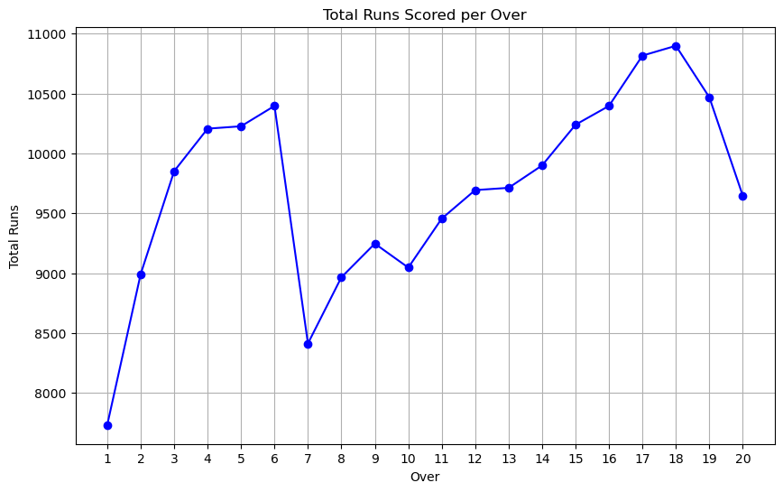

```python
runs_per_over = df.groupby('over')['total_runs'].sum().reset_index()
plt.figure(figsize=(10, 6))
plt.plot(runs_per_over['over'], runs_per_over['total_runs'], marker='o', linestyle='-', color='b')
plt.xlabel('Over')
plt.ylabel('Total Runs')
plt.title('Total Runs Scored per Over')
plt.grid(True)
plt.xticks(runs_per_over['over'])
plt.show()
```

# 16. how is the relationship between the number of runs scored and the number of extras conceded?

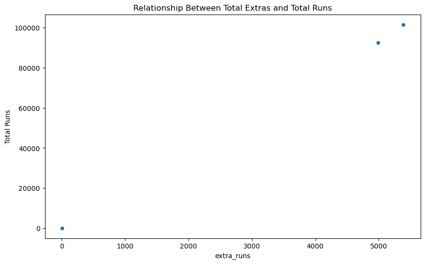

```python
import matplotlib.pyplot as plt
import seaborn as sns
df['total_extras'] = df[['wide_runs', 'bye_runs', 'legbye_runs', 'noball_runs', 'penalty_runs']].sum(axis=1)
aggregated_data = df.groupby('inning').agg({'total_runs': 'sum', 'extra_runs': 'sum'}).reset_index()
plt.figure(figsize=(10, 6))
sns.scatterplot(x='extra_runs', y='total_runs', data=aggregated_data)
plt.xlabel('extra_runs')
plt.ylabel('Total Runs')
plt.title('Relationship Between Total Extras and Total Runs')
```

# 17. Are there any notable trends in the distribution of runs scored by batting teams across innings?

```
                   batting_team  inning  total_runs
0           Chennai Super Kings       1       12693
1           Chennai Super Kings       2        8197
2           Chennai Super Kings       3           9
3               Deccan Chargers       1        6765
4               Deccan Chargers       2        4698
5              Delhi Daredevils       1        9625
6              Delhi Daredevils       2       12317
7              Delhi Daredevils       4          11
8                 Gujarat Lions       1        2267
9                 Gujarat Lions       2        2589
10                Gujarat Lions       4           6
11              Kings XI Punjab       1       12288
12              Kings XI Punjab       2       10755
13              Kings XI Punjab       3          15
```

[output cut: 25 more lines]

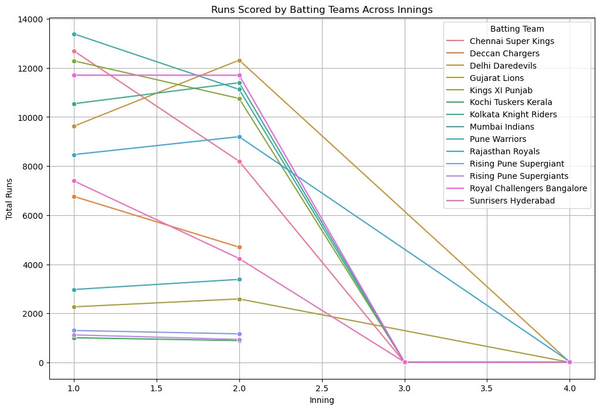

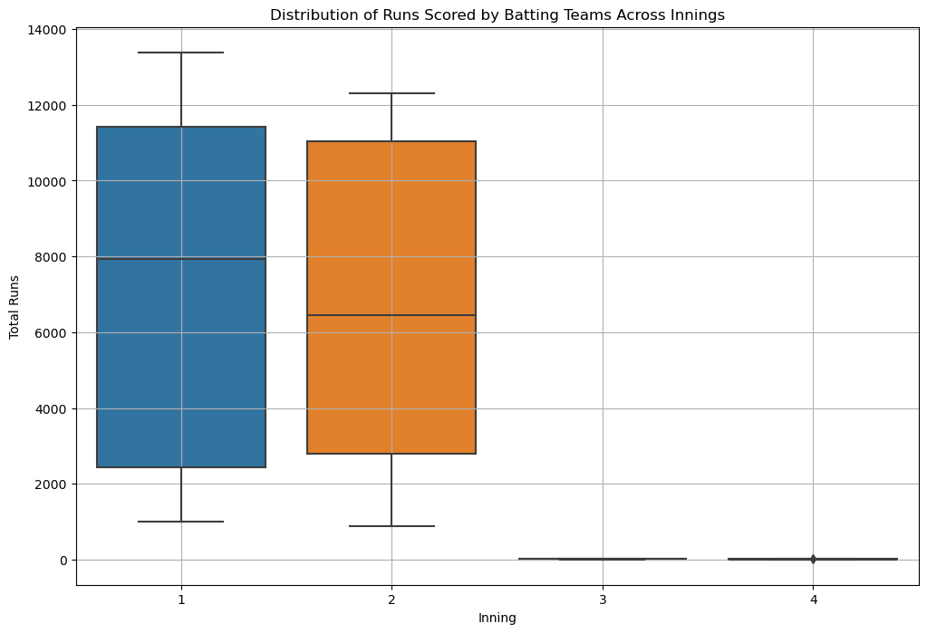

```python
team_inning = df.groupby(['batting_team', 'inning'])['total_runs'].sum().reset_index()
print(team_inning)

import matplotlib.pyplot as plt
import seaborn as sns

plt.figure(figsize=(12, 8))
sns.lineplot(x='inning', y='total_runs', hue='batting_team', data=team_inning, marker='o')
plt.xlabel('Inning')
plt.ylabel('Total Runs')
plt.title('Runs Scored by Batting Teams Across Innings')
plt.legend(title='Batting Team')
plt.grid(True)

plt.figure(figsize=(12, 8))
sns.boxplot(x='inning', y='total_runs', data=team_inning)
plt.xlabel('Inning')
plt.ylabel('Total Runs')
plt.title('Distribution of Runs Scored by Batting Teams Across Innings')
plt.grid(True)
```

# 18. Which batting team has the highest average runs per match?

```python
df.groupby('batting_team')['total_runs'].mean().head(1)
```

```
batting_team
Chennai Super Kings    1.326584
Name: total_runs, dtype: float64
```

# 19. What is the total runs scored by each batsman?

```python
df.groupby('batsman')['batsman_runs'].sum()
```

```
batsman
A Ashish Reddy     280
A Chandila           4
A Chopra            53
A Choudhary         25
A Flintoff          62
                  ...
YV Takawale        192
Yashpal Singh       47
Younis Khan          3
Yuvraj Singh      2591
Z Khan             117
Name: batsman_runs, Length: 461, dtype: int64
```

# 20. How does the average number of runs scored per inning vary across different bowling teams?

```python
average_runs_by_bowling_team = df.groupby('bowling_team')['total_runs'].mean().reset_index()
average_runs_by_bowling_team.columns = ['bowling_team', 'average_runs_conceded']
print(average_runs_by_bowling_team)
```

```
                   bowling_team  average_runs_conceded
0           Chennai Super Kings               1.271687
1               Deccan Chargers               1.285319
2              Delhi Daredevils               1.306685
3                 Gujarat Lions               1.435825
4               Kings XI Punjab               1.337971
5          Kochi Tuskers Kerala               1.230483
6         Kolkata Knight Riders               1.265579
7                Mumbai Indians               1.262514
8                 Pune Warriors               1.256551
9              Rajasthan Royals               1.265254
10       Rising Pune Supergiant               1.263485
11      Rising Pune Supergiants               1.308359
12  Royal Challengers Bangalore               1.318192
13          Sunrisers Hyderabad               1.289941
```

```python
average_runs_by_batting_team = df.groupby('batting_team')['total_runs'].mean().reset_index()
average_runs_by_batting_team.columns = ['batting_team', 'average_runs_scored']
print(average_runs_by_batting_team)
```

```
                   batting_team  average_runs_scored
0           Chennai Super Kings             1.326584
1               Deccan Chargers             1.268873
2              Delhi Daredevils             1.277451
3                 Gujarat Lions             1.363432
4               Kings XI Punjab             1.311129
5          Kochi Tuskers Kerala             1.201643
6         Kolkata Knight Riders             1.274885
7                Mumbai Indians             1.294462
8                 Pune Warriors             1.168106
9              Rajasthan Royals             1.272316
10       Rising Pune Supergiant             1.300000
11      Rising Pune Supergiants             1.305696
12  Royal Challengers Bangalore             1.325716
13          Sunrisers Hyderabad             1.286377
```

# 21. how is the relationship between the number of wides and the number of no balls bowled?

```
   inning  total_wides  total_noballs
0       1         2904            342
1       2         2736            307
2       3            1              2
3       4            1              2
```

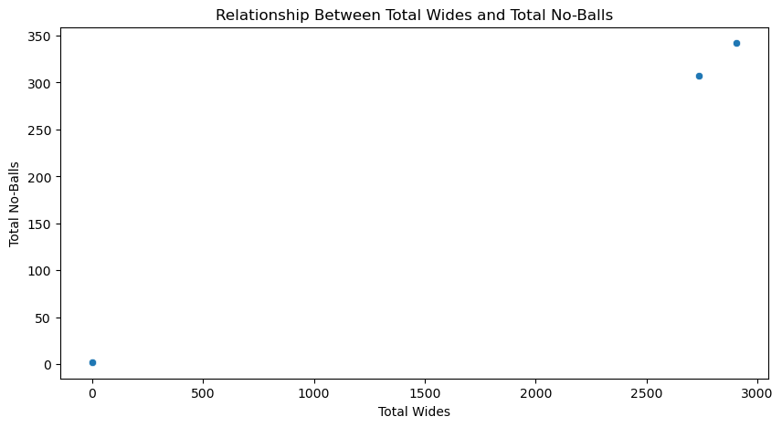

```python
df['total_wides'] = df['wide_runs']
df['total_noballs'] = df['noball_runs']
aggregated_data = df.groupby('inning').agg({'total_wides': 'sum', 'total_noballs': 'sum'}).reset_index()

print(aggregated_data)

import matplotlib.pyplot as plt
import seaborn as sns
plt.figure(figsize=(10, 5))
sns.scatterplot(x='total_wides', y='total_noballs', data=aggregated_data)
plt.xlabel('Total Wides')
plt.ylabel('Total No-Balls')
plt.title('Relationship Between Total Wides and Total No-Balls')
```

# 22. Which batting team has the highest number of centuries?

```python
centuries_df = df[df['batsman_runs'] >=100]
centuries_by_team = centuries_df.groupby('batting_team')['batsman'].count().reset_index()
centuries_by_team.columns=['batting_team','centuries']
centuries_by_team = centuries_by_team.sort_values(by='centuries',ascending=False)
print(centuries_by_team)

centuries_check = df[df['batsman_runs'] >= 100]
print(centuries_check)
```

```
Empty DataFrame
Columns: [batting_team, centuries]
Index: []
Empty DataFrame
Columns: [match_id, inning, batting_team, bowling_team, over, ball, batsman, non_striker, bowler, is_super_over, wide_runs, bye_runs, legbye_runs, noball_runs, penalty_runs, batsman_runs, extra_runs, total_runs, player_dismissed, dismissal_kind, fielder, total_extras, total_wides, total_noballs]
Index: []

[0 rows x 24 columns]
```

```python
centuries_check = df[df['batsman_runs'] >= 100]
print(centuries_check)
```

```
Empty DataFrame
Columns: [match_id, inning, batting_team, bowling_team, over, ball, batsman, non_striker, bowler, is_super_over, wide_runs, bye_runs, legbye_runs, noball_runs, penalty_runs, batsman_runs, extra_runs, total_runs, player_dismissed, dismissal_kind, fielder, total_extras, total_wides, total_noballs]
Index: []

[0 rows x 24 columns]
```

# 23. How does the number of wides vary with the over number?

```python
df.groupby('over')['wide_runs'].mean()
```

```
over
1     0.059441
2     0.055126
3     0.045260
4     0.037332
5     0.035433
6     0.039034
7     0.042162
8     0.033466
9     0.032797
10    0.029381
11    0.023735
12    0.028807
13    0.031648
14    0.029724
15    0.033257
16    0.034643
17    0.036494
18    0.038831
19    0.040348
20    0.042131
Name: wide_runs, dtype: float64
```

# 24. What is the average number of runs scored per inning in matches with a super over ?

```python
super_over_matches = df[df['is_super_over'] == 1]['match_id'].unique()
regular_innings = df[(df['is_super_over'] == 0) & (df['match_id'].isin(super_over_matches))]
average_runs_per_inning = regular_innings['total_runs'].mean()
print(f"The average number of runs scored per inning in matches with a super over is: {average_runs_per_inning:.2f}")
```

```
The average number of runs scored per inning in matches with a super over is: 1.22
```

# 25. How does the number of extras vary with the over number?

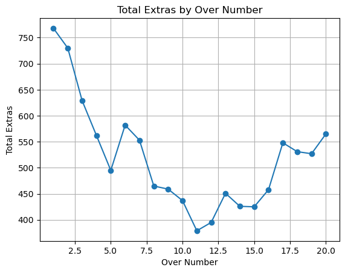

```python
extras_numbers = df.groupby('over')['extra_runs'].sum().reset_index()
plt.plot(extras_numbers['over'], extras_numbers['extra_runs'], marker='o')
plt.xlabel('Over Number')
plt.ylabel('Total Extras')
plt.title('Total Extras by Over Number')
plt.grid(True)
plt.show()
```

# 26. Which bowler has the highest economy rate?

```python
df['Total_Bowlers_runs'] = df[['wide_runs', 'noball_runs']].sum(1)
df.columns
df['economic rate']=df['Total_Bowlers_runs']/df['over']
df['economic rate'].max()
```

```
5.0
```

# 27. How does the number of dismissals vary across different dismissal kinds?

```python
df['dismissal_kind'].describe().value_counts()
```

```
dismissal_kind
7438      1
9         1
caught    1
4373      1
Name: count, dtype: int64
```

```python
df['dismissal_kind'].value_counts()
```

```
dismissal_kind
caught                   4373
bowled                   1382
run out                   755
lbw                       455
stumped                   243
caught and bowled         211
retired hurt                9
hit wicket                  9
obstructing the field       1
Name: count, dtype: int64
```

# 28. What is the distribution of runs scored by each batting team in super overs

[output not shown]

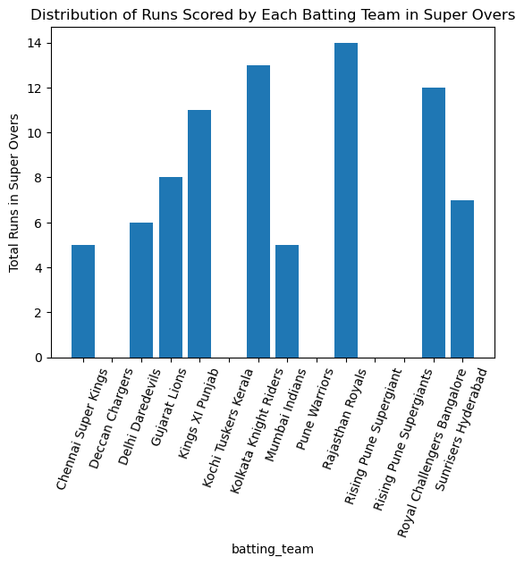

```python
import matplotlib.pyplot as plt
runs_distribution = df.groupby('batting_team')['is_super_over'].sum().reset_index()
plt.bar(runs_distribution['batting_team'], runs_distribution['is_super_over'])
plt.xlabel('batting_team')
plt.ylabel('Total Runs in Super Overs')
plt.title('Distribution of Runs Scored by Each Batting Team in Super Overs')
plt.xticks(rotation=70)
```